# Categorical Statistics

Tiffany Dunn

2020-05-08T00:00:00-00:00

Here is a revision of a final project I submitted in Fall of 2019 for an Analysis of Categorical Data Analysis course at UC Davis. The goal of this project was to complete an exploratory data analysis and determine the best predictors of byssinosis in textile workers.

## Final Project

### Introduction

In 1973, a large cotton textile company in North Carolina participated in a study to investigate the prevalence of byssinosis, a form of pneumoconiosis to which workers exposed to cotton dust are subject. Data was collected on 5,419 workers, including:

- Type of work place [1 (most dusty), 2 (less dusty), 3 (least dusty)]
- Employment, years [< 10, 10-19, 20-]
- Smoking [Smoker, or not in last 5 years]
- Sex [Male, Female]
- Race [White, Other]
- Byssinosis [Yes, No]

In this report, I will aim to evaluate the effect of the level of dust in the work place, length of employment, smoking status, sex, and / or race has on the odds that a person will get byssinosis. In order to analyze this data, I will make use of categorical data analysis methods, due to the categorical nature of which this data was collected. Before any analysis was made, it would first be important to set the variable of type of work place as a factor with levels of 1, 2, and 3. After understanding the nature of what this data looks like I will move to fit a model to the given data, as well as, make inference on which of the predicted variables recorded offer a significant effect on the presence of byssinosis in a given subject. Our goal in using model fitting in this way would be to make further predictions on a person’s risk for contracting the disease if more data were to be collected.

### Explotatory Data Analysis

We’ll begin our analysis by looking at a descriptive summary of the data collected. To accomplish this, I can look at a plot of multiple boxplots measuring byssinosis by one predictor split up by its levels:

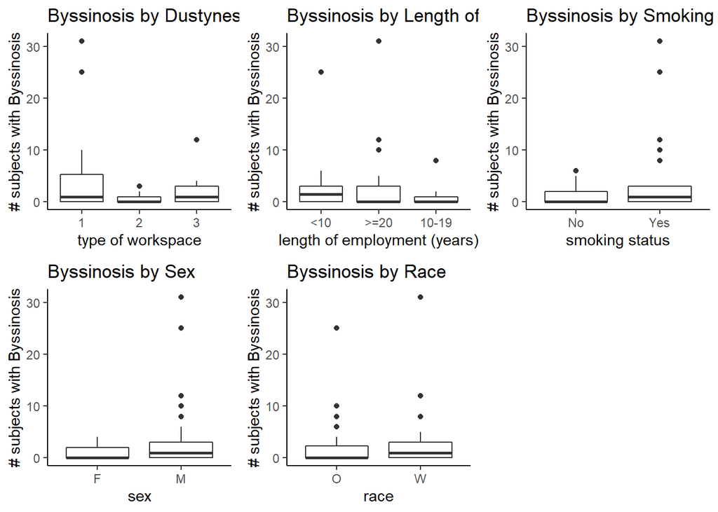

```r
library(ggplot2)
library(plyr)
library(gridExtra)
b.data = read.csv("Byssinosis.csv")
b.data$Workspace = as.factor(b.data$Workspace)

plot1 <- ggplot(data = b.data, mapping = aes(x = Workspace, y = Byssinosis)) +
  labs(title="Byssinosis by Dustyness of Workspace",x="type of workspace", y = "# subjects with Byssinosis") +
  theme_classic() +
  geom_boxplot()
plot2 <- ggplot(data = b.data, mapping = aes(x = Employment, y = Byssinosis), main = "Bysinosis status by Employment length") +
  labs(title="Byssinosis by Length of Employment",x="length of employment (years)", y = "# subjects with Byssinosis") +
  theme_classic() +
  geom_boxplot()
plot3 <- ggplot(data = b.data, mapping = aes(x = Smoking, y = Byssinosis)) +
  labs(title="Byssinosis by Smoking Status",x="smoking status", y = "# subjects with Byssinosis") +
  theme_classic() +
  geom_boxplot()
plot4 <- ggplot(data = b.data, mapping = aes(x = Sex, y = Byssinosis)) +
  labs(title="Byssinosis by Sex",x="sex", y = "# subjects with Byssinosis") +
  theme_classic() +
  geom_boxplot()
plot5 <- ggplot(data = b.data, mapping = aes(x = Race, y = Byssinosis)) +
  labs(title="Byssinosis by Race",x="race", y = "# subjects with Byssinosis") +
  theme_classic() +
  geom_boxplot()
grid.arrange(plot1,plot2,plot3,plot4,plot5, ncol=3)
```

Figure 1 gives us a general idea of the spread of the data by variable and factor level. From this plot, I am able to see which variables have different distributions between its factor levels. The difference in distribution across factor levels may give us a hint as to which variables are going to be important to us later on during model selection. For example, as displayed in Figure 1, the variable race had factor levels white and other, it appears that both levels have roughly the same distribution of number of subjects that were diagnosed with byssinosis. Just from this I could guess that race is not going to have a significant effect on byssinosis. Similar assumptions could be made, but more inferential statistics will have to be done to make any significant conclusions.